##### 5.

Create a data frame with the following columns. Each row corresponds to a single $\text{Binomial}(n,p)$ distribution. The first two columns are the parameters of the distribution.

- `n`, which ranges from 10 to 1000 by 10s $(10, 20, 30, \ldots, 1000)$
- `p`, which is always equal to $0.7$
- `mu`, the mean
- `sigma`, the standard deviation
- `q90`, the 0.9 quantile (or 90th percentile)
- `prob_1`, $\mathsf{P}(\mu - 10 \le X \le \mu + 10)$, the probability that the random variable is within 10 of the mean
- `prob_2`, $\mathsf{P}(0.69 \le X/n \le 0.71)$, the probability that the sample proportion $\hat{p} = X/n$ is within 0.01 of $p$.

**Note that $\mathsf{P}(0.69 \le X/n \le 0.71)$ if and only if $\mathsf{P}(0.69n \le X \le 0.71n)$.**

-5a. Create the data frame. Then print the first 20 rows of it.

```r
# Create n and p vectors
n <- seq(10, 1000, by = 10)
p <- rep(0.7, length(n))

# Calculate mu and sigma
mu <- n * p
sigma <- sqrt(n * p * (1 - p))

# Calculate q90
q90 <- qbinom(0.9, size = n, prob = p)

# Calculate prob_1
prob_1 <- pbinom(mu + 10, size = n, prob = p) - pbinom(mu - 10 - 1, size = n, prob = p)

# Calculate prob_2
prob_2 <- pbinom(0.71 * n, size = n, prob = p) - pbinom(0.69 * n - 1, size = n, prob = p)

# Create the data frame
binomial_df <- data.frame(n, p, mu, sigma, q90, prob_1, prob_2)

# Print the first 20 rows
head(binomial_df, 20)
```

```
##      n   p  mu    sigma q90    prob_1    prob_2
## 1   10 0.7   7 1.449138   9 1.0000000 0.4669489
## 2   20 0.7  14 2.049390  17 0.9999995 0.3559010
## 3   30 0.7  21 2.509980  24 0.9999631 0.2988525
## 4   40 0.7  28 2.898275  32 0.9997138 0.2626420
## 5   50 0.7  35 3.240370  39 0.9988949 0.2370470
## 6   60 0.7  42 3.549648  46 0.9971192 0.2177228
## 7   70 0.7  49 3.834058  54 0.9941721 0.2024661
## 8   80 0.7  56 4.098780  61 0.9900300 0.1900246
## 9   90 0.7  63 4.347413  69 0.9847921 0.1796268
## 10 100 0.7  70 4.582576  76 0.9786144 0.2563298
## 11 110 0.7  77 4.806246  83 0.9716677 0.3195709
## 12 120 0.7  84 5.019960  90 0.9641148 0.3069096
## 13 130 0.7  91 5.224940  98 0.9561007 0.2956429
## 14 140 0.7  98 5.422177 105 0.9477495 0.2855322
## 15 150 0.7 105 5.612486 112 0.9391647 0.2763925
## 16 160 0.7 112 5.796551 119 0.9304313 0.2680777
## 17 170 0.7 119 5.974948 127 0.9216182 0.2604708
## 18 180 0.7 126 6.148170 134 0.9127809 0.2534767
## 19 190 0.7 133 6.316645 141 0.9039634 0.2470173
## 20 200 0.7 140 6.480741 148 0.8952008 0.3001913
```

-5b. Make a plot of `q90` versus `n` (`n` is on the x axis). Describe the pattern you see.

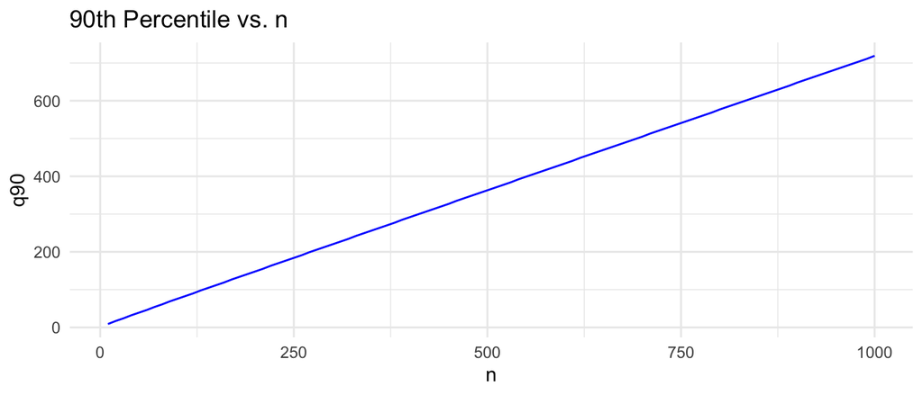

```r
# Plot of q90 versus n
ggplot(binomial_df, aes(x = n, y = q90)) +
  geom_line(color = "blue") +
  xlab("n") +
  ylab("q90") +
  ggtitle("90th Percentile vs. n") +
  theme_minimal()
```

> As the sample size (n) increases, the 90th percentile (q90) of the binomial distribution also increases, indicating a spread in the distribution tails.

-5c. Make a plot of `prob_1` versus `n`. How does the probability that $X$ is within a fixed width interval around $\mu$ change as `n` increases?

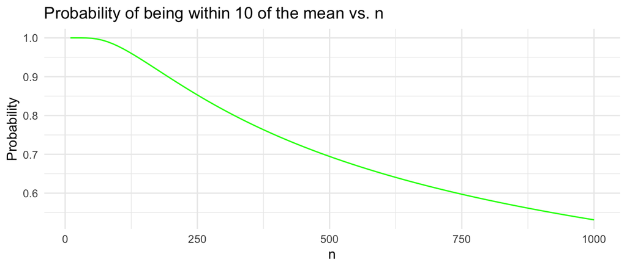

```r
# Plot of prob_1 versus n
ggplot(binomial_df, aes(x = n, y = prob_1)) +
  geom_line(color = "green") +
  xlab("n") +
  ylab("Probability") +
  ggtitle("Probability of being within 10 of the mean vs. n") +
  theme_minimal()
```

-5d. Make a plot of `prob_2` versus `n`. How does the probability that the sample proportion is within a fixed width interval around `p` change as `n` increases?

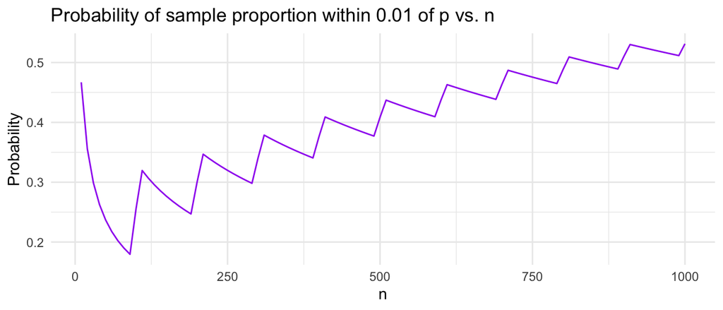

```r
# Plot of prob_2 versus n
ggplot(binomial_df, aes(x = n, y = prob_2)) +
  geom_line(color = "purple") +
  xlab("n") +
  ylab("Probability") +
  ggtitle("Probability of sample proportion within 0.01 of p vs. n") +
  theme_minimal()
```

##### 6.

Suppose that $X \sim N(200, 40)$, ($X$ has a normal distribution with mean $\mu = 200$ and standard deviation $\sigma = 40$).

-6a. Make a graph of this normal distribution.

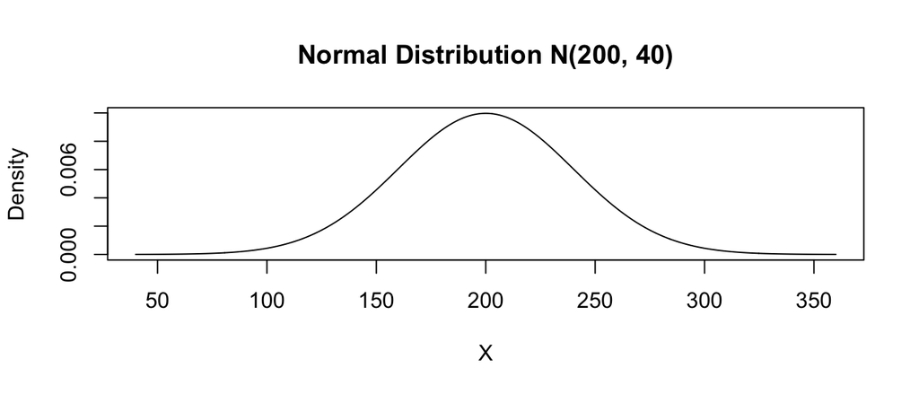

```r
# Parameters
mu <- 200
sigma <- 40

# Generate x values
x <- seq(mu - 4*sigma, mu + 4*sigma, length.out = 1000)

# Calculate the normal density
density <- dnorm(x, mean = mu, sd = sigma)

# Plot the normal distribution
plot(x, density, type = "l", xlab = "X", ylab = "Density", main = "Normal Distribution N(200, 40)")
```

-6b. Find $P(X > 250)$. Create a graph of the normal density with the corresponding interval $X > 250$ shaded.

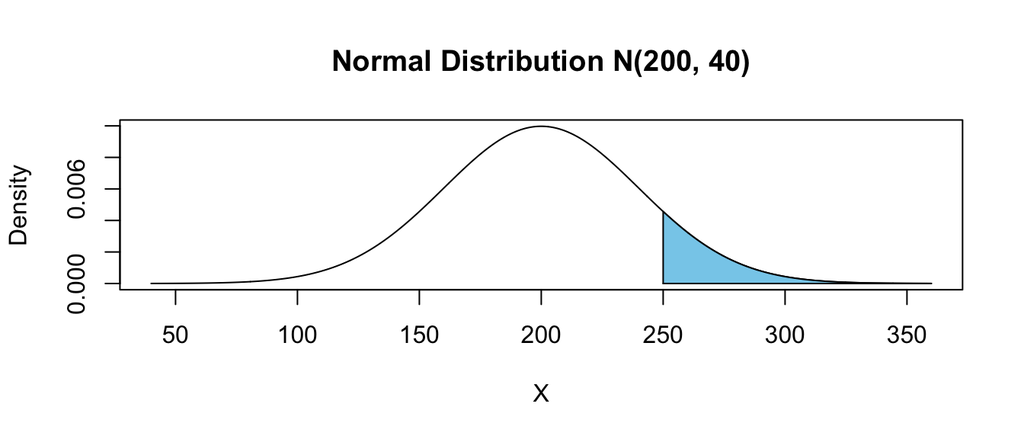

```r
# Probability X > 250
prob_X_gt_250 <- 1 - pnorm(250, mean = mu, sd = sigma)

# Graph with shaded area for X > 250
plot(x, density, type = "l", xlab = "X", ylab = "Density", main = "Normal Distribution N(200, 40)")
x_shaded <- seq(250, mu + 4*sigma, length.out = 1000)
y_shaded <- dnorm(x_shaded, mean = mu, sd = sigma)
polygon(c(x_shaded, rev(x_shaded)), c(rep(0, length(x_shaded)), rev(y_shaded)), col = "skyblue")
```

-6c. For what value $z$ is $P(Z > z)$ equal to $P(X > 250)$ where $Z$ is a standard normal random variable?

```r
# Standardize X = 250
z_score <- (250 - mu) / sigma

# Find z such that P(Z > z) = P(X > 250)
z_for_X_gt_250 <- qnorm(prob_X_gt_250)
z_for_X_gt_250
```

```
## [1] -1.25
```

-6d. Find a number $a$ such that $P(200 - a < X < 200 + a) = 0.70$. Create a graph which shows the normal density with the interval from $200 -a$ to $200 + a$ shaded.

```r
# Probability of X within a certain range
target_prob <- 0.70

# Find 'a' such that P(200 - a < X < 200 + a) = 0.70
a <- qnorm((1 + target_prob) / 2, mean = mu, sd = sigma) - mu
a
```

```
## [1] 41.45734
```

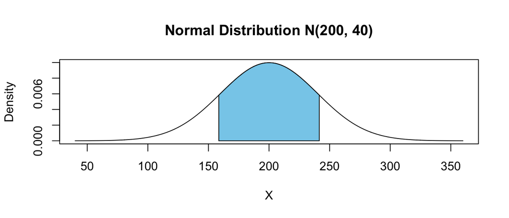

```r
# Graph with shaded area for the interval
plot(x, density, type = "l", xlab = "X", ylab = "Density", main = "Normal Distribution N(200, 40)")
x_shaded <- seq(mu - a, mu + a, length.out = 1000)
y_shaded <- dnorm(x_shaded, mean = mu, sd = sigma)
polygon(c(x_shaded, rev(x_shaded)), c(rep(0, length(x_shaded)), rev(y_shaded)), col = "skyblue")
```

##### 7.

Assume that the total number of points scored in an NCAA men’s college basketball game is approximately normal (true values are discrete, but we approximate with a continuous distribution) with a mean $\mu = 145.25$ and a standard deviation $\sigma = 18.51$.

-7a. In what proportion of games do we expect the total points scored to be 160 or more? (**Note: to correct for continuity, use 159.5.**)

```r
# Parameters
mu <- 145.25
sigma <- 18.51

# Probability of total points scored 160 or more
prob_gt_160 <- 1 - pnorm(159.5, mean = mu, sd = sigma)
prob_gt_160
```

```
## [1] 0.2206932
```

-7b. What is the (approximate) probability that the mean total points per game in a random sample of 10 games is more than 160?

```r
# Sample size
n <- 10

# Adjusted mean for sample mean
mu_sample <- mu

# Adjusted standard deviation for sample mean
sigma_sample <- sigma / sqrt(n)

# Probability of sample mean more than 160
prob_sample_mean_gt_160 <- 1 - pnorm(160, mean = mu_sample, sd = sigma_sample)
prob_sample_mean_gt_160
```

```
## [1] 0.005869187
```

##### 8.

Consider the same NCAA basketball scoring distribution from the previous problem. Find a value $a$ where there is about a ten percent change that the total score of a random game is $a$ or higher, assuming a good approximation to a normal distribution.

```r
# Parameters
mu <- 145.25
sigma <- 18.51

# Probability of total score of a random game being 'a' or higher
prob_a_or_higher <- 0.10

# Find 'a' using the quantile function
a <- qnorm(1 - prob_a_or_higher, mean = mu, sd = sigma)
a
```

```
## [1] 168.9715
```